# ESLII 8章後半

# $\S$ 8.6 MCMC for Sampling from the Posterior

一般に事後分布からのサンプリングは難しい． この節では事後分布からのサンプリングにマルコフ連鎖モンテカルロ（MCMC)を扱う．

- ギブスサンプリングがEMアルゴリズムと関連していることを見る．
  - 主な違いは条件付き分布を最大化するのではなく，条件付き分布からサンプリングすることである．
- 参考資料『計算統計学II』，『リーディングDAT講座資料 L-B1. 統計モデリング入門』

### ギブスサンプリング

以下の問題を考えよ．

確率変数$U_1$,$U_2$, $\ldots$, $U_K$の同時分布からのサンプリング
$$U_1,U_2,\ldots, U_K \sim p(U_1,U_2, \ldots, U_K)$$
を行いたい．

ただし同時分布からのサンプリングは難しく，一方，条件付き分布からのサンプリング
$$U_j \sim p(U_j |U_1,U_2, . . . ,U_{j−1},U_{j+1}, \ldots ,U_K),\ j = 1, 2, \ldots ,K$$
は容易だと仮定する．

- ギブスサンプリングは各成分を順番に条件付き分布からサンプリングする手法である．
- この過程が定常状態になると，目的の同時分布からのサンプルを与える．
- この手続きをAlgorithm 8.3に示した．

Algorithm 8.3 ギブスサンプラー

1. 初期値$U_k^{(0)}, k = 1,2,\ldots,K$をとる．$t \gets 1$とする．
2. $U_k^{(t)} \sim p(U^{(t)}_k|U^{(t)}_1,...,U^{(t)}_{k−1},U^{(t-1)}_{k+1},...,U^{(t-1)}_K)$を生成する．$k = 1,2,\ldots,K$．
3. 同時分布$(U^{(t)}_1,\ldots,U^{(t)}_K)$が定常になるまで$t \gets t+1$としてステップ2を繰り返す．
- 異なる$t$に対して，$(U_1^{(t)}, \ldots, U_K^{(t)})$は独立ではない．しかし正則条件（非周期性・釣り合い条件とかか）のもとでギブスサンプリングはいずれ定常状態に至ることが示せる．
- ギブスサンプリングは$U_k$の周辺分布を不変にするので，ギブスサンプリングの定常分布は真の同時分布となる．

### 余談

- 条件付き分布の明示的な式は必要ない．分布からのサンプルがありさえすればよい．
- ギブスサンプリングが定常状態になれば，周辺分布はサンプルからの密度推定により近似できる．
  - ただし条件付き分布$p(U_k |U_l, l\neq k)$が明示的に与えられれば，周辺分布のよりよい推定が可能である．
  - 例えば$U_k$の周辺分布は以下の式で与えられる．(Exercise 8.3):
    $$\hat{p}_{U_k}(u) =
    \frac{1}{(M − m + 1)}
    \sum_{t=m}^Mp(u|U^{(t)}_l,\ l \neq k).$$
    ここでバーンインのため最初の$m-1$個のサンプルを使っていない．
  - 周辺分布は以下の式で与えられるからそんなものだろう．ここで$\check{U}_k$は，$U_k$を除くという意味．
    $$\begin{eqnarray}
    p(U_k)
    &=&\int p(U_1,\ldots, U_K)dU_1\ldots d\check{U}_k\ldots dU_K \\
    &=&\int p(U_k | U_1,\ldots, \check{U}_k,\ldots, U_K)p_{\check{k}}(U_1,\ldots, \check{U}_k,\ldots, U_K)dU_1\ldots d\check{U}_k\ldots dU_K \\
    &=&\mathrm{E}_{p_{\check{k}}}[p(U_k | U_1,\ldots, \check{U}_k,\ldots, U_K)]. \\
    \mathrm{E}_p[A] &\simeq& \frac{1}{M}\sum_{i=1}^M A(x_1^i,\ldots, x_n^i),\ x_1^i,\ldots, x_n^i \sim p(X_1,\ldots, X_n).
    \end{eqnarray}$$

### 例：ガウス混合分布をギブスサンプリング

- データ$Z$が与えられたときにパラメータを同時分布からサンプリングしたい．
- もしデータ$Z$と他のパラメータが与えられたときに，簡単に条件付き分布からサンプリングできるならばギブスサンプリングが役に立つ．
- 事後分布からのギブスサンプリングと指数型分布族のEMアルゴリズムには密接な関連がある．
- $\S$ 8.5.1の混合ガウス分布の例を使ってこれを示す．
  - EMアルゴリズムの潜在データ$\Delta_i$を，パラメータとみなすことがポイント．
- 簡単のため分散$\sigma_1^2$, $\sigma_2^2$と混合比率$\pi$を最尤法の推定値で定める． よって未知のパラメータは平均$\mu_1$, $\mu_2$である．パラメータを$(\mu_1, \mu_2, \Delta_i)$とする．

問題

以下の観測値から混合ガウス分布のパラメータ$(\mu_1, \mu_2, \Delta_i)$を推定せよ．
$$\begin{eqnarray}
-0.39\ 0.12\ 0.94\ 1.67\ 1.76\ 2.44\ 3.72\ 4.28\ 4.92\ 5.53\\
0.06\ 0.48\ 1.01\ 1.68\ 1.80\ 3.25\ 4.12\ 4.60\ 5.28\ 6.22
\end{eqnarray}$$

$$\begin{eqnarray}
Y_1 &\sim& \mathrm{N}(\mu_1, \hat\sigma_1^2),\ \hat\sigma_1^2 = 0.87,\\\
Y_2 &\sim& \mathrm{N}(\mu_2, \hat\sigma_2^2),\ \hat\sigma_2^2 = 0.77,\\
\Delta_i &\sim& \mathrm{Bel}(\hat\pi),\ \hat\pi = 0.546,\\
y_i &=& (1-\Delta_i)\cdot Y_1 + \Delta_i\cdot Y_2.
\end{eqnarray}$$

- この問題のギブスサンプラーはAlgorithm 8.4で与えられる．

Algorithm 8.4 混合ガウス分布に対するギブスサンプリング

1. 初期値をとる．$\theta^{(0)} = (\mu_1^{(0)}, \mu_2^{(0)})$.
2. $t = 1, 2, \ldots$に対して以下を繰り返す．
1. $i = 1, 2, \ldots ,N$に対して，確率$p(\Delta_i^{(t)} = 1) = \hat{\gamma}_i(\theta^{(t)})$で$\Delta_i^{(t)} \in \{0, 1\}$を生成する．(8.42)
   $$\hat{\gamma}_i(\theta^{(t)}) = \frac{\hat{\pi}\phi_{(\mu_2^t,\hat\sigma_2^2)}(y_i)}{(1-\hat{\pi})\phi_{(\mu_1^t,\hat\sigma_1^2)}(y_i) + \hat{\pi}\phi_{(\mu_2^t,\hat\sigma_2^2)}(y_i)}.$$
2. 以下のように定め，（$Y_1, Y_2$に属すると推定した$y_i$の平均）
   $$\hat{\mu}_1 =
   \frac{\sum^N_{i=1}(1 − \Delta^{(t)}_i ) \cdot y_i}{\sum^N_{i=1}(1 − \Delta^{(t)}_i )},\
   \hat{\mu}_2 =
   \frac{\sum^N_{i=1} \Delta^{(t)}_i\cdot y_i}{\sum^N_{i=1}\Delta^{(t)}_i}
   ,$$
   $\mu_1^{(t)} \sim \mathrm{N}(\hat{\mu}_1, \hat{\sigma}_1^2)$と$\mu_2^{(t)} \sim \mathrm{N}(\hat{\mu}_2, \hat{\sigma}_2^2)$を生成する．
3. 同時分布$(\Delta^{(t)}, \mu_1^{(t)} , \mu_2^{(t)})$が変わらなくなるまでステップ2を繰り返す．
- ステップ2(a)と2(b)は，Algorithm 8.1 最尤法のEステップとMステップの尤度最大化がサンプリングに変わったものとなる．
  - ステップ2(a)では最大尤度負担率$\gamma_i = \mathrm{E}(\Delta_i|\theta,Z)$を計算する代わりに，潜在データ$\Delta_i$を分布$p(\Delta_i|\theta,Z)$からサンプリングする．
  - ステップ2(b)では，事後分布$p(\mu_1, \mu_2, \Delta |Z)$を最大化する代わりに，条件付き分布$p(\mu_1, \mu_2|\Delta,Z)$からサンプリングする．

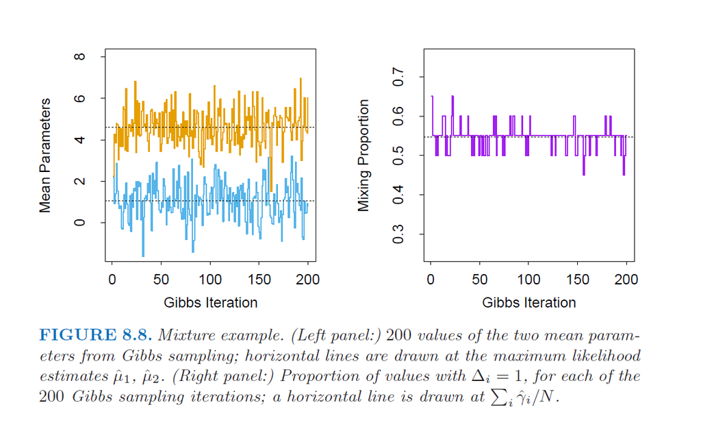

- 図8.8にギブスサンプリング200回の試行を示す． 水平の破線は最尤推定値$\hat{\mu}_1^{(t)}$, $\hat{\mu}_2^{(t)}$, $\sum_i\hat{\gamma}_i(\theta^{(t)})/N$である． 値は速やかに収束し，最尤推定値4.62, 1.06, 0.546の周りに分布している．
- 上記混合モデルはギブスサンプリングとEM法の関係を明らかにするために単純化した．
  - より現実的には，分散と混合比率に事前分布$p(\sigma_1^2, \sigma_2^2,\pi)$を与え，個別のギプスサンプリングのステップを含むようにする．また平均に事前分布$p(\mu_1, \mu_2)$を組み込んでもよい．
  - これらの事前分布はimproperではいけない．なぜなら$\pi=0\ \mathrm{or}\ 1$となるからだそうだ．

### R code

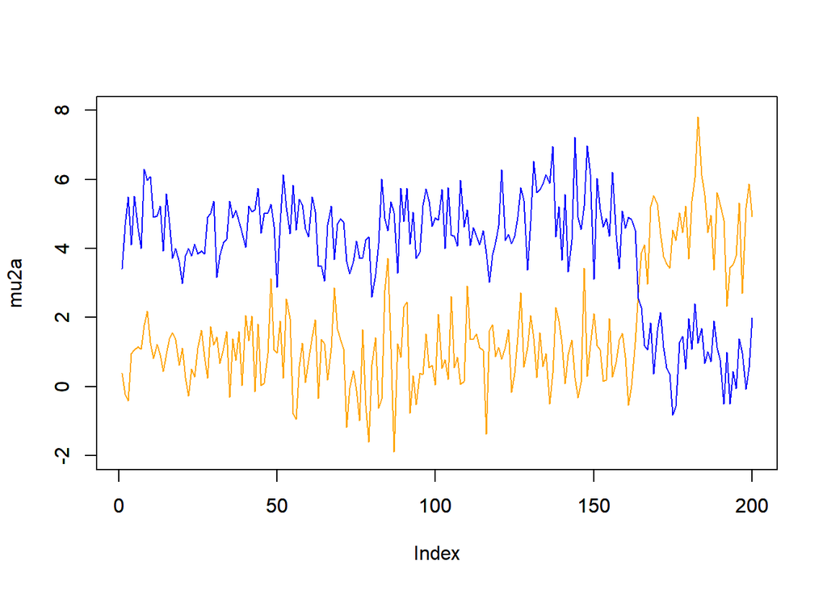

```r
pi <- 0.546
sig1 <- 0.87
sig2 <- 0.77
y <- c(-0.39, 0.12, 0.94, 1.67, 1.76, 2.44, 3.72, 4.28, 4.92, 5.53,
0.06, 0.48, 1.01, 1.68, 1.80, 3.25, 4.12, 4.60, 5.28, 6.22)
mu1 <- sample(y,1)
mu2 <- sample(y,1)
Delta <- numeric(20)
N <- 200
gama <- numeric(N)
mu1a <- numeric(N)
mu2a <- numeric(N)
for (n in 1:N) {
  gamsum <- 0
  for (i in 1:20) {
    den1 <- dnorm(y[i], mean=mu1, sd=sqrt(sig1))
    den2 <- dnorm(y[i], mean=mu2, sd=sqrt(sig2))
    gam <- pi*den2/((1-pi)*den1+pi*den2)
    gamsum <- gamsum+gam
    Delta[i] <- rbinom(1,1,gam)
  }
  gama[n] <- gamsum/20
  mu1h <- sum((1-Delta)*y)/sum(1-Delta)
  mu2h <- sum(Delta*y)/sum(Delta)
  mu1 <- rnorm(1, mean=mu1h, sd=sqrt(sig1))
  mu2 <- rnorm(1, mean=mu2h, sd=sqrt(sig2))
  mu1a[n] <- mu1
  mu2a[n] <- mu2
}
plot(mu1a, ylim=c(-2,8), ann=F, type="l", col="orange")
par(new=T)
plot(mu2a, ylim=c(-2,8), type="l", col="blue")
```

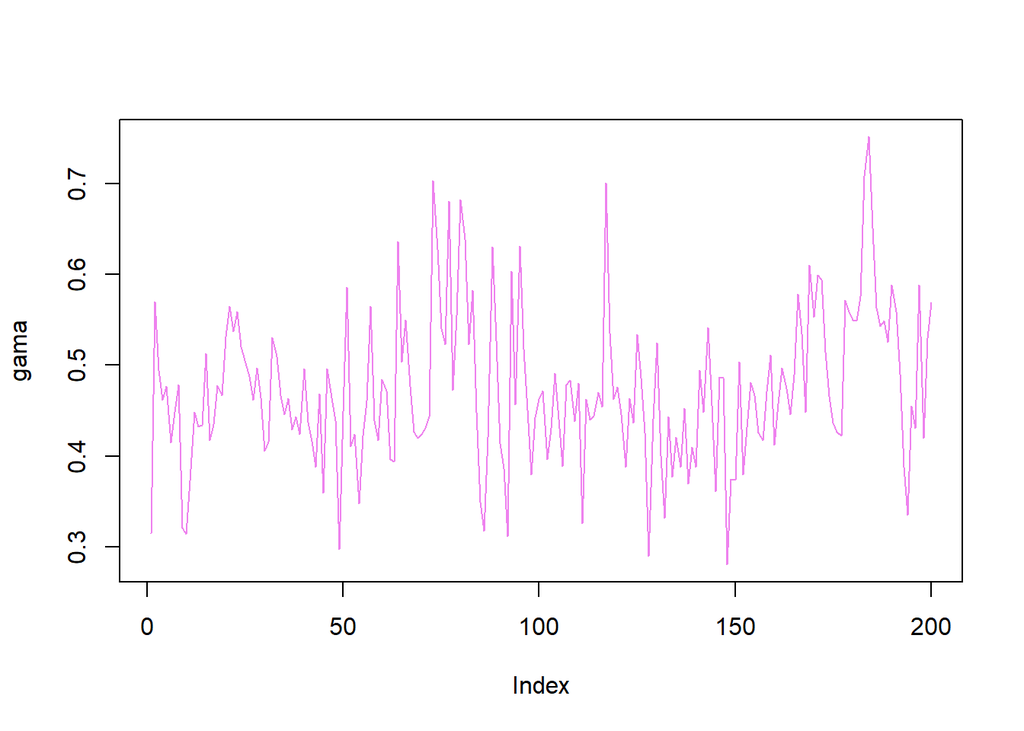

```r
plot(gama, type="l", col="violet")
```

```r
mean(mu1a)
```

```
## [1] 1.579693
```

```r
mean(mu2a)
```

```
## [1] 4.0085
```

```r
mean(gama)
```

```
## [1] 0.4728635
```

### その他

- 事後分布からサンプリングする方法は，他にもメトロポリス・ヘイスティングス法などがある．
- これらの方法はガウス過程やニューラルネットワークに応用されている．詳細は章末の文献を見よ．

# $\S$ 8.7 Bagging (Bootstrap aggregation)

前にブートストラップをパラメータ推定や予測の正確さを評価する方法として導入した． ここでは推定や予測を改善するためのブートストラップの使い方を示す．

$\S$ 8.4ではブートストラップ平均はベイズ事後平均に近似的に等しくなることを示した． バギングはさらにこの関係を調べる．

### まず回帰問題

- モデルを訓練データ$Z = \{(x_1, y_1), \ldots , (x_N, y_N)\}$に当てはめ，予測$\hat{f}(x)$を得たとしよう．
- ブートストラップサンプル$Z^{∗b}$, $b = 1, \ldots ,B$に対して，モデルを当てはめ予測$\hat{f}^{∗b}(x)$を与える．
- バギングはこれらの$\hat{f}^{∗b}(x)$を平均する．それゆえ分散を減らす．
- バギング推定値$\hat{f}_{\mathrm{bag}}(x)$は以下の式で与えられる．
  $$\hat{f}_{\mathrm{bag}}(x) = \frac{1}{B}\sum_{b=1}^B\hat{f}^{*b}(x)$$
- 真のバギング推定値は以下で定義される．
  $$\mathrm{E}_{\hat{P}}\hat{f}^*(x)$$
  ここで$\hat{P}$は全てのサンプル$(x_i, y_i)$に等しい確率$1/N$を与える経験分布，また$Z^* = \{(x^*_1 , y^*_1), \ldots , (x^*_N, y^*_N)\}$，$(x^*_i, y^*_i) \sim \hat{P}$である．
  - つまりこうか？
    $$\mathrm{E}_{\hat{P}}\hat{f}^{*}(x) = \sum_{n_1+\cdots +n_N=N}\frac{N!}{n_1!\cdots n_N!}\left(\frac{1}{N}\right)^N\hat f^{*}(x),\$$
    ここで$\hat f^*(x)$は，$(x_1, y_1)$が$n_1$回，$\cdots$ $(x_N, y_N)$が$n_N$回のブートストラップサンプルに対する予測．パラメトリック？
- $\hat{f}_{\mathrm{bag}}(x)$は$\mathrm{E}_{\hat{P}}\hat{f}^{*}(x)$のモンテカルロ推定値であり，$B \to \infty$のとき$\hat{f}_{\mathrm{bag}}(x) \to \mathrm{E}_{\hat{P}}\hat{f}^{*}(x)$．
- バギング推定値$\hat{f}_{\mathrm{bag}}(x)$は元の推定値$\hat{f}(x)$が非線形や適応的関数（adaptive function p.282, l.-6. 定義何？）であるときに$\hat{f}(x)$と異なる．
  - 例えば$\S$ 8.2.1のBスプラインをバギング推定すると，左下のパネルのカーブを平均することになる．

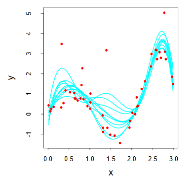

  - Bスプラインはデータに関して線形であるので，入力値を固定して考える．
  - 等式(8.6) $y_i^* = \hat\mu(x_i) + \epsilon_i^*, \epsilon_i^*\sim \mathrm{N}(0, \hat\sigma^2)$のパラメトリックブートストラップを使ってサンプリングすると，$\hat{f}_{\mathrm{bag}}(x) \to \hat{f}(x)$ as $B \to \infty$となる．(Exercise 8.4略). それゆえバギングは図8.2の左上のカーブを推定する．

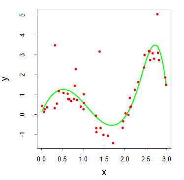

- もしノンパラメトリックなブートストラップでバギングをしたとしても結果はほぼ等しいそうだ．

### より面白い例：回帰ツリー（$\S$ 9）

- このとき$\hat{f}(x)$は入力特徴量$x$に対するツリーの予測結果である．
- 各ブートストラップサンプルから得られたツリー（ブートストラップツリー）は大抵元のツリー$\hat{f}(x)$と異なる入力特徴量を使用する．また異なる数の終端ノードを持つこともある．
- バギング推定値はこれらのブートストラップツリーの予測結果の平均である．

#### 分類の推定値

- 今ツリーが$K$クラス分類器$\hat{G}(x)$を作成したとしよう．
  - ここで簡単のため指示ベクトル関数$\hat{f}(x)\in \{0,1\}^N$を定義する．$\hat{f}(x)$は$\hat{G}(x) = k$のとき第$k$成分が1，残りの成分は0と定める．（$\hat{G}(x) = \mathrm{argmax}_k\hat{f}(x)$）．
- $B$個のブートストラップサンプルから$B$本のツリー$\hat{f}^{*b}(x)$を作成する．
- バギング推定値$\hat{f}_{\mathrm{bag}}(x)$は，
  $$\hat{f}_{\mathrm{bag}}(x) = \frac{1}{B}\sum_{b=1}^B\hat{f}^{*b}(x) = (p_1(x), p_2(x), \ldots, p_K(x))$$
  である．ここで$p_k(x)$は入力$x$に対してクラス$k$を予測したツリーの割合．（$\sum p_k(x) = 1$）．
- バギング分類器は$\hat{G}_{\mathrm{bag}}(x) = \mathrm{argmax}_k \hat{f}_{\mathrm{bag}}(x) = \mathrm{argmax}_k \{p_k(x)\}$である．つまり最も多く予測されたクラスを選択する．

#### クラス確率の推定値

- 時には$x$の分類結果よりもクラス確率の推定値が欲しくなる．
- 上記$p_k(x)$をクラス確率の推定値としたくなるが，これは駄目である．
  - 単純な2クラス分類器を考えよう．
  - クラス1の真の確率が0.75で，各ブートストラップ分類器が正確にクラス1を予測したとしよう（ブートストラップ分類器がたくさんあるときにそんなことあるのか？）．このとき$p_1(x) = 1$となるが，これは間違い．
- しかしながら多くの分類器$\hat{G}(x)$には，$x$のクラス確率を推定する潜在関数$\hat{f}(x)$が存在する． (例えばツリーでは終端ノードでのクラス比率がそれにあたる，らしい).
  - バギングとして指示ベクトル関数の代わりにこの潜在関数$\hat{f}(x)$を平均することが考えられる．
  - この方法はクラス確率の推定値を改善するだけではなく，（特に小さな$B$に対して）バギング分類器をより低い分散にする傾向があるそうだ．(図8.10).

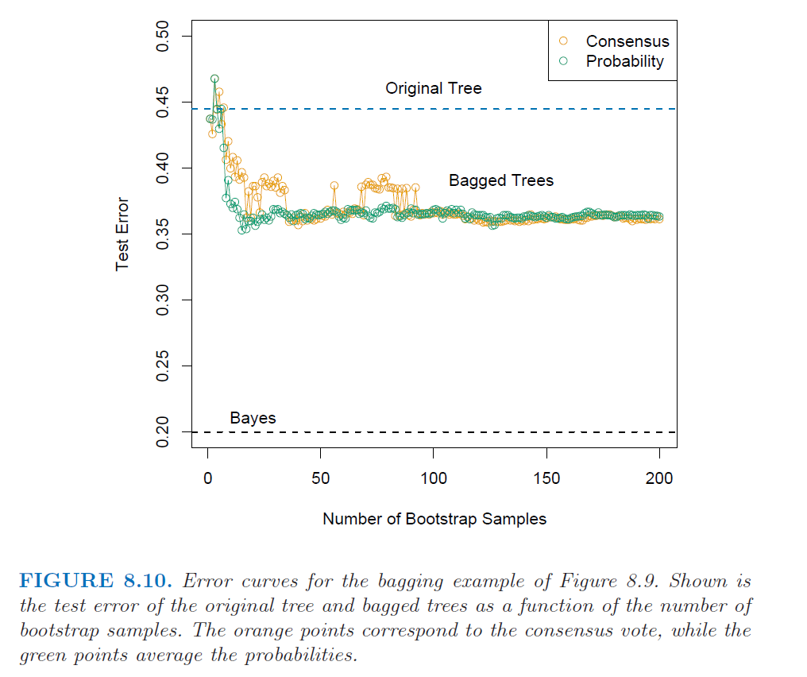

## $\S$ 8.7.1 Example: Trees with Simulated Data

### バギングが有用な例

設定

- 2つのクラス$\{0,1\}$と5つの特徴$\vec{x} =\ ^t(x_1, x_2, x_3, x_4, x_5)$をもつサンプル$\{Y_i, \vec{x}_i\}$を30個生成する．
  $$\begin{eqnarray}
  \vec{x} &\sim& \mathrm{N}(\vec{0}, \Sigma), \\
  Y &\sim& p(Y),
  \end{eqnarray}$$
  ここで$\Sigma$, $p(Y)$は以下のように定義される．
  $$\begin{eqnarray}
  &&\Sigma = \begin{pmatrix}
  1 & 0.95 & 0.95 & 0.95 & 0.95\\
  0.95 & 1 & 0.95 & 0.95 & 0.95\\
  0.95 & 0.95 & 1 & 0.95 & 0.95\\
  0.95 & 0.95 & 0.95 & 1 & 0.95\\
  0.95 & 0.95 & 0.95 & 0.95 & 1\\
  \end{pmatrix}, \\
  &&\left\{
  \begin{array}{rr}
  p(Y = 1|x_1 \le 0.5) = 0.2,\\
  p(Y = 1|x_1 > 0.5) = 0.8.
  \end{array}
  \right.
  \end{eqnarray}$$
- ベイズ誤差（ベイズ分類器$\hat{G}_{\mathrm{bag}}(x) = \mathrm{argmax}_k p(Y=k|x)$の 誤分類率）は0.2である．
- サイズ2000のテストサンプルも同じ分布から生成する．
- 分類ツリーを訓練データと各200のブートストラップデータに当てはめる．(分類ツリーは$\S$ 9.2で説明する). 刈込は行わない．
- 図8.9に元のツリーと11本のブートストラップツリーを示す．
  - ツリーが異なる分岐とカットポイントをもち，全て異なることに注目せよ．

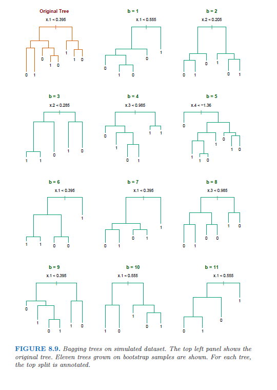

- 図8.10に元のツリーとバギングツリーのテスト誤差を示した．（再掲）

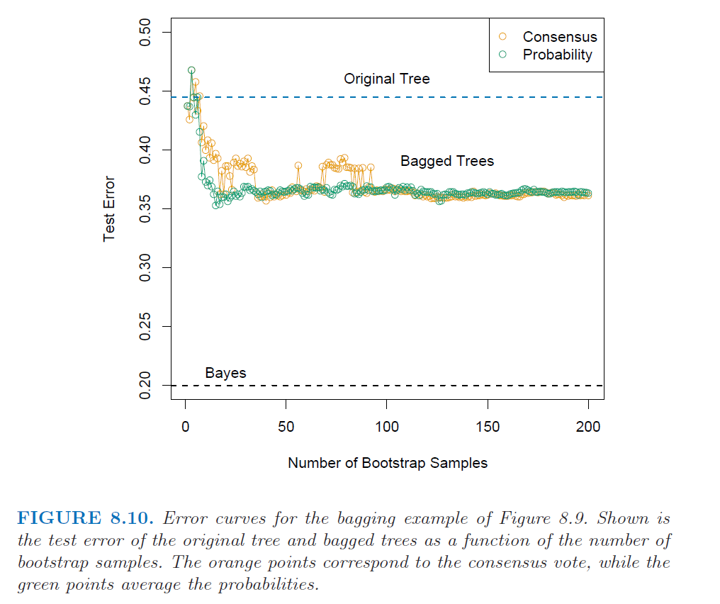

- この例ではツリーは入力特徴量の相関のため大きな分散をもつ．
  - ブートストラップサンプルから作ったツリーが雑多という意味らしい．データが少し違うだけで大きく違った分類が行われる．$\S$ 9.2参照．木の不安定性と書いてある．
- バギングはこの分散を取り除き，テスト誤差を減らした．

### R code

参考:https://www1.doshisha.ac.jp/~mjin/R/Chap_19/19.html

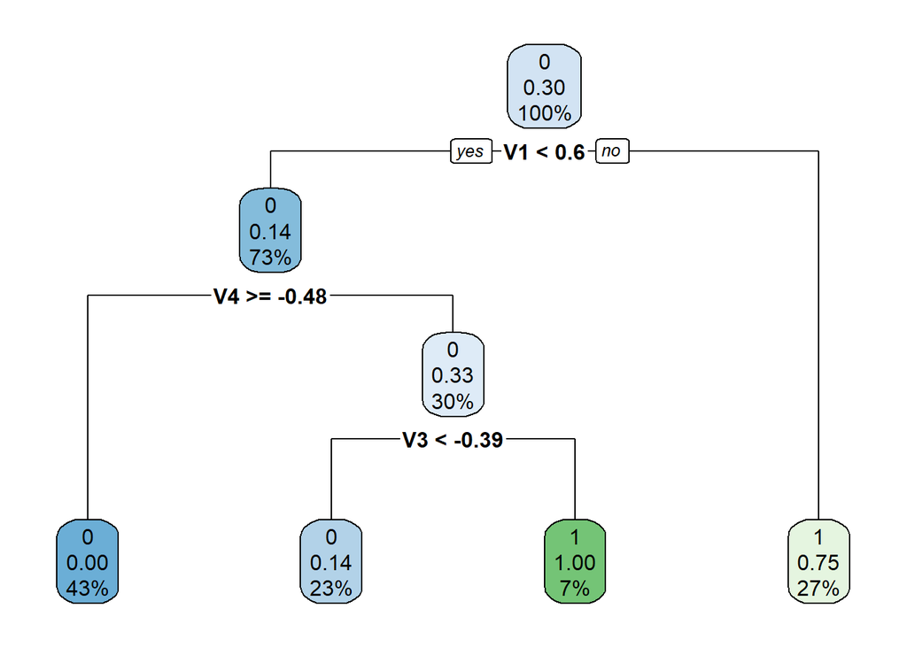

```r
library(mvtnorm)
library(rpart)
library(rpart.plot)
Sigma <- matrix(rep(0.95,5^2),5,5)+diag(5)*0.05
x <- rmvnorm(30, c(0,0,0,0,0), Sigma)
# cor(x)
xdf <- as.data.frame(x)
xdf <- xdf %>%
  bind_cols(DOWN=rbinom(30,1,0.2), UP=rbinom(30,1,0.8))
xdf <- xdf %>%
  mutate(Y = ifelse(V1<=0.5, DOWN, UP)) %>%
  mutate(Y = as.factor(Y))
#オリジナル・ツリー
fit <- rpart(Y ~ V1+V2+V3+V4+V5, data=xdf, method='class', minsplit=5)
rpart.plot(fit)
```

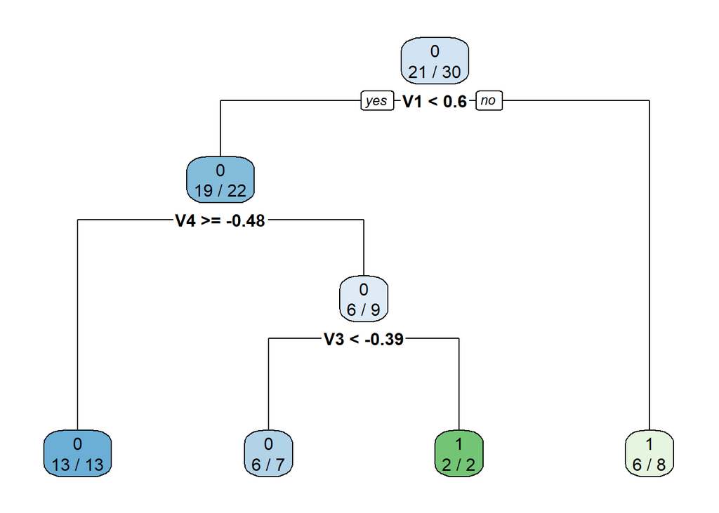

```r
rpart.plot(fit, extra=2)
```

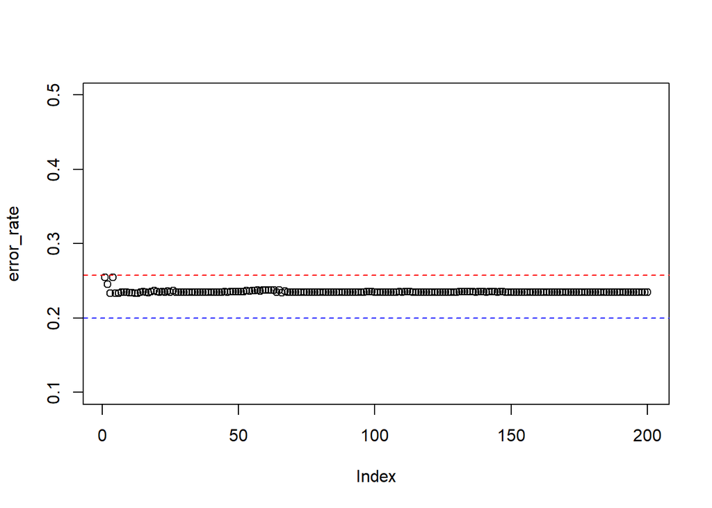

```r
#test data
testN <- 2000
test <- rmvnorm(testN, c(0,0,0,0,0), Sigma)
testdf <- as.data.frame(test)
testdf <- testdf %>%
  bind_cols(DOWN=rbinom(testN,1,0.2), UP=rbinom(testN,1,0.8))
testdf <- testdf %>%
  mutate(Y = ifelse(V1<=0.5, DOWN, UP)) %>%
  mutate(Y = as.factor(Y))
#original tree error
testpr <- predict(fit, testdf, type="class")
testtbl <- table(testdf$Y, testpr)
origin_error <- 1-sum(diag(testtbl))/sum(testtbl)

error_rate = numeric(200)
cumpr <- numeric(2000)
for (i in 1:200) {
  xdfbs <- sample_n(tbl=xdf, size=30, replace=TRUE)
  fit <- rpart(Y ~ V1+V2+V3+V4+V5, data = xdfbs, method='class', minsplit=5)
  bspr <- predict(fit, testdf, type="class")
  cumpr <- cumpr + (bspr==1)
  testpr <- (cumpr*1.0/i >= 0.5)
  testtbl <- table(testdf$Y, testpr)
  error_rate[i] <- 1-sum(diag(testtbl))/sum(testtbl)
}
plot(error_rate, ylim = c(0.1, 0.5))
abline(h=origin_error, lty=2, col="red")
abline(h=0.2, lty=2, col="blue")
```

### なぜバギングが2乗誤差損失のもとで役に立つか

- 要するに平均がバイアスを変えないまま分散を減らすからである．（平均すれば期待値は同じなのでバイアスは変わらず，分散は$1/n$）．
- $f_{\mathrm{ag}}(x) = \mathrm{E}_{P}\hat{f}^∗(x)$を（データからではなく）真の分布$P$からのブートストラップによるバギング推定値とする．
  - そのため実際には計算できない推定値であるが，解析目的には便利である．
  - 訓練データ$(x_i, y_i)$, $i = 1, \ldots, N$は真の分布$P$から独立にサンプリングされたと仮定する．
  - ここで$x$は固定され，ブートストラップサンプル$Z^*$は$P$からサンプルされた点 $(x_i^*, y_i^*)$, $i = 1, 2, . . . ,N$から成る．
  - 以下のように書ける．

$$\begin{eqnarray}
\mathrm{E}_P[(\hat{f}^∗(x) - y)^2]
&=& \mathrm{E}_P[(\hat{f}^∗(x) − f_{\mathrm{ag}}(x) + f_{\mathrm{ag}}(x) − y)^2] \\
&=& \mathrm{E}_P[(\hat{f}^∗(x) − f_{\mathrm{ag}}(x))^2] + (f_{\mathrm{ag}}(x) − y)^2 \\
&\ge& (f_{\mathrm{ag}}(x) − y)^2.
\end{eqnarray}$$

- バギング（訓練データからブートストラップサンプリングして平均すること）は右辺の余分な誤差$\mathrm{E}_P[( \hat{f}^∗(x) − f_{\mathrm{ag}}(x))^2]$を減らすことを示唆する．

### 上記の議論は0-1損失のもとでの分類器に対しては成立しない

- なぜならバイアスと分散の加法性が成立しないからである．
- この状況では，バギングはよい分類器をよりよくできるが，悪い分類器を悪化させうる．
- ランダム化を使った単純な例を示す．
  - $y = 1$と定める．分類器$\hat{G}(x)$は，任意の$x$に対して確率0.4で$y = 1$と予測し，確率0.6で$y = 0$と予測するものとする．（悪い分類器）．
  - このとき$\hat{G}(x)$の誤分類率は0.6であるが，バギング分類器$\hat{G}_{\mathrm{bag}}(x) = \mathrm{argmax}_k \hat{f}_{\mathrm{bag}}(x) = \mathrm{argmax}_k (0.6,0.4)=0$の誤分類率は1.0である．

### 集合知

- バギングの分類に対する効果は，独立な弱い学習器の多数決の観点から理解できる．(Dietterich, 2000a).
- 2クラス分類問題の例における，入力$x$に対するベイズ最適決定を$G(x) = 1$とする．
- 各弱い学習器$G_b^*$が誤答率$e_b = e < 0.5$をもつとし，$S_1(x) = \sum^B_{b=1}I(G_b^*(x) = 1)$をクラス1への投票とする．
- 弱い学習器は独立と仮定しているので，$S_1(x) ∼ \mathrm{Bin}(B, 1 − e)$であり，また$B$が大きくなるとき$p(S_1 > B/2) \to 1$である．
  $$\frac{S_1(x)-B(1-e)}{\sqrt{Be(1-e)}} > \frac{B/2 - B(1-e)}{\sqrt{Be(1-e)}} = \frac{B(e-1/2)}{\sqrt{Be(1-e)}}\to -\infty$$
  より$p(S_1 > B/2)\to p(z > -\infty) = 1$．
- この概念は統計学の外部で「集合知」と人気を博した．(Surowiecki, 2004)
- 多様で独立した人々の知識の集約は，（大体において）個人の知識よりも勝り，多数決によって活用できる．
  - もちろんここでの主な注意事項は「独立」である．そしてバギングツリーは独立ではない．
- 図8.11がシミュレートした例における多数決の力を説明する（略）．
  - ここでは50人中30%だけの投票者が各カテゴリーの知識をもつと設定した．

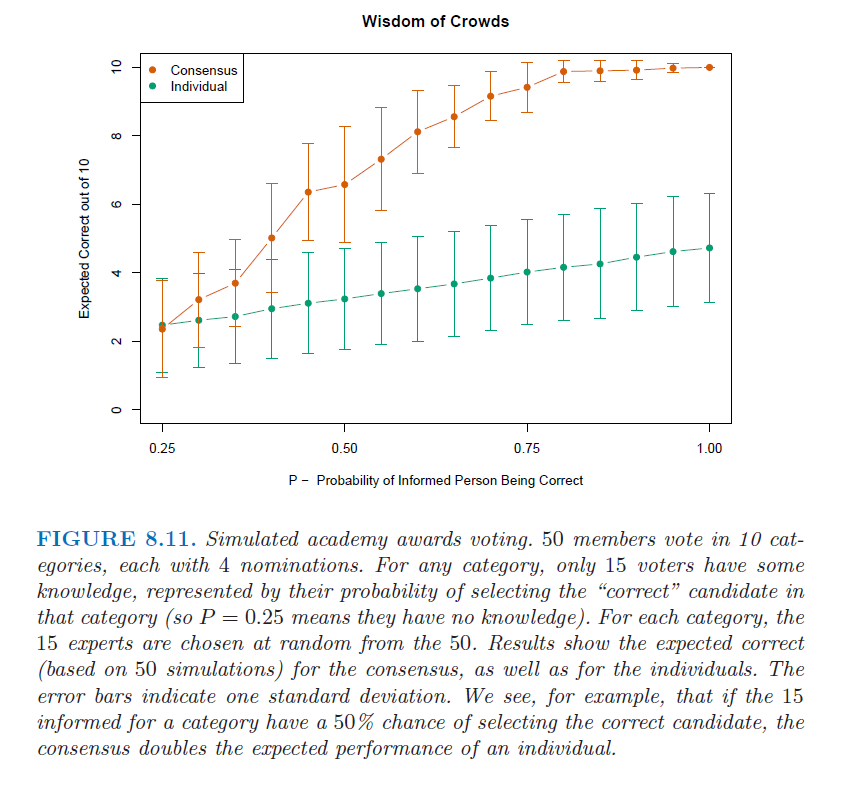

### 閑話

- $\S$ 15ではランダムフォレストがサンプルしたツリーの相関を減らすことでバギングを改善することを見る．
- バギングをするとモデルのどのような単純な構造も失われることに注意せよ．
  - 例えばバギングツリーはもはやツリーではない．指示ベクトル関数を使うことでツリーの構造は失われた．モデルを解釈する際には欠点である．
  - 最近傍法のような安定した手法（データが少々異なってもほとんど同じ分類が行われる）はバギングにそれほど影響されない．
  - 残念なことに，バギングが役に立つ（不安定な）モデルは，解釈性に重点を置くがゆえに不安定であり，さらに解釈性はバギングによって失われる．

### バギングが無用な例

- 図8.12にバギングが役に立たない例を示す．

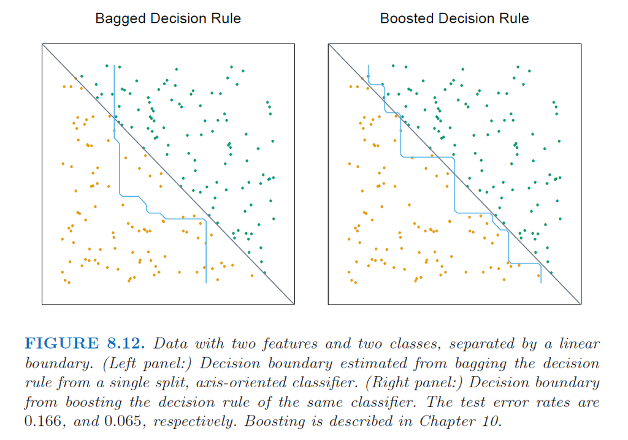

- 100点のデータは2つの入力特徴$(x_1,x_2)$をもつ．各データのクラス（青・オレンジ）は直線$x_1 + x_2 = 1$の分割する領域によって定まる．
- ブートストラップサンプルに使う分類器$\hat{G}(x)$を，$x_1$軸または$x_2$軸に平行な直線による平面の分割の中で，正答率が最大となる分割として定める．
  - 正答率は多分$a\times (a+2b)/2 + b\times(2a+b)/2, b=1-a, 0\le a\le 1$．

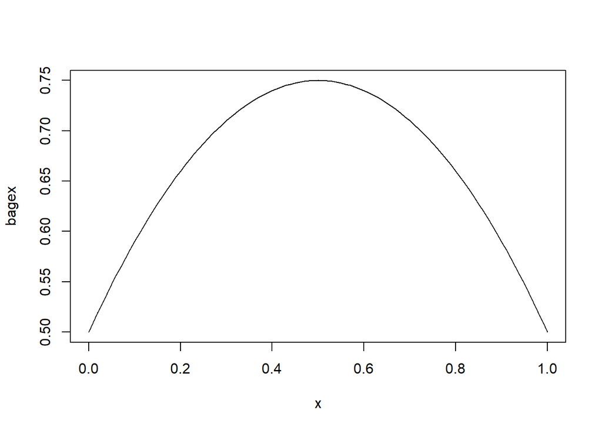

```r
bagex <- function(a) {
  a*(a+2-2*a)/2 + (1-a)*(2*a+1-a)/2
}
plot(bagex, 0, 1)
```

- $B = 50$のバギングから決定境界を得て左のパネルに青い曲線で示した．真の境界からはかけ離れている．
  - $\hat{G}(x)$は中心$(1/2,1/2)$の周辺で平面を分割し，それゆえ中心$(1/2,1/2)$から離れるとほとんど役に立たない．
- ここではクラス確率の平均も役に立たない，そうである．
  - バギングは単一分類器のクラス確率を平均してクラス確率を予測する．
  - バギングから計算された期待クラス確率はどのような単一の分類器でも実現できない．この意味でバギングは分類器のモデル空間を拡大している．が，拡大不足なので，この例では役に立たない．
- $\S$ 10で説明する「ブースティング」は大幅なモデル空間の拡大を実行する方法である．
  - 右のパネルの決定境界はブースティングの結果であり，大まかに実際の境界を捉えている．

# $\S$ 8.8 Model Averaging and Stacking（読み物）

- $\S$ 8.4ではブートストラップ推定値をノンパラメトリックベイズモデルの観点からパラメータの近似とみた．
- このようにみるとバギング推定値は事後ベイズ平均の近似とみなせる．
  - 一方，訓練データ推定値$\hat{f}(x)$は事後分布のモードに相当する．
- 事後平均は2乗誤差損失を最小にするので，バギングが平均2乗誤差を減らすのは驚くべきことではない．

### ベイズモデル平均

- ここではベイズモデル平均をより一般に議論する．
- 訓練データ$Z$に対して，候補モデルの集合$\mathcal{M}_m$, $m = 1, \ldots, M$がある．
  - これらのモデルは，同じタイプのモデルで異なるパラメータの値をもつもの（例えば線形回帰モデル）かもしれないし，異なるタイプのモデル（ニューラルネットワークと回帰ツリー）かもしれない．
- $\zeta$が興味の対象の値であるとせよ．例えばある入力特徴量$x$での予測$f(x)$である．
- $\zeta$の事後分布と期待値は以下で与えられる．
  $$p(\zeta | Z) = \sum_{m=1}^Mp(\zeta|\mathcal{M}_m, Z)p(\mathcal{M}_m | Z), \\
  \mathrm{E}[\zeta | Z] = \sum_{m=1}^M\mathrm{E}[\zeta|\mathcal{M}_m, Z]p(\mathcal{M}_m | Z).$$
  - このベイズ予測は個々の予測の重み付き平均である．重みは各モデルの事後確率に比例する．

### 異なるモデル平均手法

- **合議法**(Committee methods)：$p(\mathcal{M}_m | Z)=1/M$．単純に各モデルの予測値の平均を使う．つまり各モデルは同じ確率をもつ．
- BIC：$p(\mathcal{M}_m | Z)=\mathrm{BIC}(\mathcal{M}_m)$．BICを事後モデル確率の推定値に使った（$\S$ 7.7）．
  - BICは$\mathcal{M}_m$, $m = 1, \ldots, M$が同じタイプで異なるパラメータの値をもつモデルの場合に適用可能である．
  - BICは各モデルに，どのくらい適合するか，どのくらい多くのパラメータを使っているかによって，重みを与える．
- フルベイズの手法：もし各モデル$\mathcal{M}_m$がパラメータ$\theta_m$をもてば，以下のように書ける．
  $$\begin{eqnarray}
  p(\mathcal{M}_m | Z) &\propto&
  p(\mathcal{M}_m)p(Z | \mathcal{M}_m)\\
  &=&
  p(\mathcal{M}_m)\int p(Z | \theta_m, \mathcal{M}_m)p(\theta_m | \mathcal{M}_m)d\theta_m\\
  \end{eqnarray}$$
  - 原理上は事前分布$p(\theta_m|\mathcal{M}_m)$を設定して，数値的に事後分布を計算してモデル平均の重みに使うことができる．
  - しかしながら，これが単純なBIC近似に比べて価値があるかは分からない．

### 頻度主義の観点からモデル平均

- 予測$\hat{f}_1(x), \hat{f}_2(x), \ldots, \hat{f}_M(x)$が与えられると，重み$w = (w_1,w_2, \ldots ,w_M)$を以下のように求めることができる．
  $$\hat{w} = \mathrm{argmin}_w \mathrm{E}_{P}\left[\left(Y - \sum_{m=1}^Mw_m\hat{f}_m(x)\right)^2\right]$$
  - ここで入力$x$は固定し，データ$Z$の中の$N$個のサンプルは分布$P$に従うとする．
  - 解$\hat{w}$は$^t\hat{F}(x) = (\hat{f}_1(x), \ldots, \hat{f}_M(x))$上の$Y$の線形回帰で与えられる．

$$\hat{w} = \mathrm{E}_{P}[\hat{F}(x)\ ^t\hat{F}(x)]^{-1}\mathrm{E}_{P}[\hat{F}(x)Y]$$

- この完全回帰は任意の単一モデルよりも誤差が小さい．argminだからである．
  $$\mathrm{E}_{P}\left[\left(Y - \sum_{m=1}^M\hat{w}_m\hat{f}_m(x)\right)^2\right]
  \le
  \mathrm{E}_{P}\left[\left(Y - \hat{f}_m(x)\right)^2\right]$$
  - つまりモデルの組み合わせ$\sum w_m\hat{f}_m(x)$は，母集団で考えれば誤差を悪化させない．
- 実際には$\hat{w}$（母集団での線形回帰）は計算できない．その代わり訓練データ上で線形回帰を行うのが自然である．
- しかしながらこれがうまくいかない例が存在する．（以下の例の何がうまくいっていないと言っているのかよく分からない）
  - $\hat{f}_m(x), m = 1, \ldots ,M$を，訓練データ$Z = \{x_i, y_i\}$の中から$m$個（$m$個以下？）のデータを使った予測の中で最善の予測とする．
    $$\hat f_m(x) = \mathrm{argmin}_{\hat f^W} \mathrm{E}_{P}\left[Y - \hat{f}^W(x)\right]^2\
    \mathrm{s.t.}\ W\subset Z, |W|\le m.$$
    すると$\hat{f}_1(x)$より$\hat{f}_2(x)$の方がよい．$\hat{f}_2(x)$より$\hat{f}_3(x)$の方がよい．以下同様．よって $\hat{w} = (0,\ldots,0,1)$, $\hat{w}_M = 1$, $\hat{w}_m = 0, (m < M)$となる．つまり$\hat{f}_M(x)$に全重みを与える．
  - $\hat{f}_M(x)$も$\sum w_m\hat{f}_m(x)$の一つだからいいのでは？

### スタッキング

- 上記の例の問題は，各モデルの複雑さ（この例では入力の数$m$）を考慮しなかったことにある．
- スタック汎化，スタッキングは各モデルの複雑さを考慮する方法である．
- $i$番目のデータを除いたモデル$m$の予測の$x$での値を$\hat{f}^{−i}_m (x)$とする．
- 重みのスタッキング推定値は，$\hat{f}^{−i}_m(x_i)$, $m = 1, \ldots ,M$上の$y_i$の最小2乗線形回帰で与えられる．
- スタッキング重みは以下で与えられる．最終的な予測は$\sum_m \hat{w}^{\mathrm{st}}_m\hat{f}_m(x)$となる．

$$\hat{w}^{\mathrm{st}} = \mathrm{argmin}_w \sum_{i=1}^N\left[y_i - \sum_{m=1}^Mw_m\hat{f}^{-i}_m(x_i)\right]^2$$

- 交差検証予測$\hat{f}^{−i}_m(x)$を使うことで，複雑なモデルに大きな重みを与えることを避けている．
- 重みを非負にしたり，総和を1にしたりすることでよりよい結果が得られることもある．
  - これは重みを事後モデル確率と解釈すれば妥当．また扱いやすい2次計画問題を導く．
- スタッキングとleave-one-out交差検証法によるモデル選択には緊密な関係がある．($\S$ 7.10).
  - もし最小化を，一つだけ1で残りは0となる重みベクトル$w$の集合に制限すると，最小のleave-one-out交差検証法誤差をもつモデル$\hat{m}$を選択する．
- スタッキングは，単一のモデルを選択するのではなく，モデルを結合した最適な重みを推定する．
  - スタッキングは大抵よい推測をもたらすが，単一モデル選択より解釈が難しい．

### その他

- スタッキングのアイディアは以上に述べたことよりも一般的である．
- モデルの結合は，線形回帰以外の学習方法も使用可能である．
  - 推測を改善するために，学習方法を他の学習方法の上に「積み上げ」る．
- 重み$w$は$x$に依存してもよい．

# $\S$ 8.9 Stochastic Search: Bumping（読み物）

- バンピングはよりよい単一モデルを探す技術である．
- バンピングはモデル空間をランダムに動くためにブートストラップを使う．
- 極小値を多くもつ問題で，バンピングは悪い解にはまってしまうことを避けてくれる．

### バンピング

- バンピングもブートストラップサンプルを作ってモデルに当てはめる．
  - バギングのように予測を平均するのではなく，バンピングは訓練データに最もよく当てはまるモデルを選ぶ．
- バンピングはブートストラップサンプル$Z^{*1},\ldots,Z^{*B}$を各モデルに当てはめて，各点$x$での予測$\hat{f}^{∗b}(x)$, $b = 1, 2,\ldots ,B$を与える．それから元の訓練データ上で最小の予測誤差を与えるモデルを選択する．
- 例えば2乗予測誤差に関しては，以下の$\hat{b}$から得られる予測モデル$\hat{f}^{*b}(x)$を選択する．
  $$\hat{b}=\mathrm{arg min}_b\sum_{i=1}^N\left(y_i - \hat{f}^{∗b}(x_i)\right)^2$$
- 慣例によりブートストラップサンプルに元の訓練データそれ自体も含める．
  - そのためこの手法は元のモデルを選択する可能性もある．
- データを摂動することによって，バンピングはモデル空間の中のよいモデルの領域に動かそうとする．
  - 例えば，少数の入力点のせいで悪いモデルを選択してしまう場合，それらの入力点を含まないブートストラップサンプルを使えばよりよいモデルを選択するだろう．

### XOR分類問題

- 例として図8.13の悪名高いXOR分類問題を考えよ．

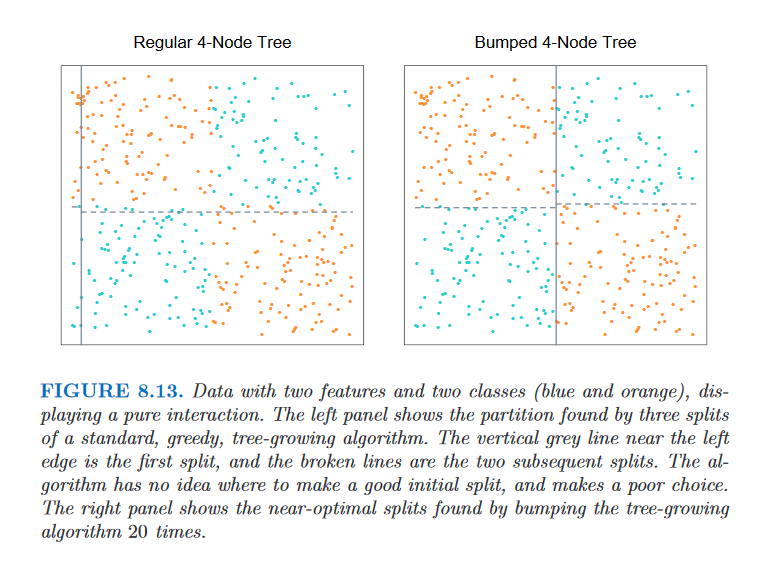

- 二つの入力特徴量$x_1, x_2$があり，特徴量の符号のXORがとクラス（青とオレンジ）を決める．
  - データをまず直線$x_1 = 0$で分割し，それから分割された各領域を直線$x_2 = 0$で分割すれば，（またはその逆）完全なツリー分類器となる．
- しかしながら（短絡的・貪欲）CARTアルゴリズム($\S$ 9.2)は分類に失敗する．
  - 座標軸に平行な直線によって最良の分割を行う．さらに分割した領域を同様に分割する．
    - 最良な分割とは，前の例のように，$x_1$軸または$x_2$軸に平行な直線による平面の分割の中で，正答率が最大となる分割らしい．
  - この問題では，最初の座標軸に平行な直線による分割がランダムな分割となってしまう．
  - 実際に見つけた分割を図8.13の左のパネルに示した．
- 一方バンピングはクラス間のバランスを破る．20個のブートストラップサンプルを使って，図8.13の右のパネルにある最適に近い分割を見つけた．
- CARTアルゴリズムの欠点は，クラスラベルと独立な（ノイズとなる）入力特徴量を追加するとさらに悪化する．
  - このときCARTアルゴリズムは入力特徴量$x_1$と$x_2$を他の入力特徴量から区別できなくなる．

### その他

- バンピングは訓練データ上で異なるモデルを比較するので，モデルを同程度に複雑なものにしなければならない．
  - ツリーの場合は，各ブートストラップサンプル上で終端ノードの数を同じ数にさせる，らしい．
- バンピングは，滑らかさを欠くため当てはめを最適化するのが難しい問題にも役立つ．
  - ブートストラップサンプル上でより簡便な規準に対して最適化し，それから訓練データ上で望む規準に対して最良の結果を与えるモデルを選べばよい．